# **Proyecto Business Performance Analysis**

Jose Alejandro Miranda, Maria Jesus Palero, Jaime Andres Salazar y Paola Rita Villar.

## **1. Preparación de los datos**

Librerías a utilizar:

```r
library(tidyverse) # tidyr, dplyr, ggplot2, purrr.....
library(DescTools) #Herramientas para estadística descriptiva y análisis de datos
library(psych) #Herramientas de entrada de datos y análisis descriptivo.
library(scales) #Herramienta complemento de "ggplot2"
library (reshape2) #Herramientas de manipulación de datos
library(ggpubr) #Complemento de ggplot
library(ggplot2);theme_set(
  theme_bw() +
    theme(legend.position = "right")) ## Tema por defecto a los gráficos
library(ggsci) #Paletas de colores para graficos
library(corrplot)
```

Durante todo el análisis se trabaja con la base de datos suministrada “`Dataset_Compradores.csv`”, la cual, para su estandarización, se extrae desde URL. Además, por indicaciones durante clase, la última variable `Exited` no se tiene en cuenta.

```r
data_ori <- read.csv("https://raw.githubusercontent.com/Lermaa2/ProjectoFinal-BPA/68c182ad59e0039875994b11acfcd40a66949acd/Dataset_Compradores.csv"
                 ,dec=".")

dat <- data_ori[2:13]; glimpse(dat);tail(dat[,1:4])
```

```
## Rows: 10,000
## Columns: 12
## $ CustomerId      <int> 15634602, 15647311, 15619304, 15701354, 15737888, 1...
## $ Surname         <chr> "Hargrave", "Hill", "Onio", "Boni", "Mitchell", "Ch...
## $ CreditScore     <int> 619, 608, 502, 699, 850, 645, 822, 376, 501, 684, 5...
## $ Geography       <chr> "France", "Spain", "France", "France", "Spain", "Sp...
## $ Gender          <chr> "Female", "Female", "Female", "Female", "Female", "...
## $ Age             <int> 42, 41, 42, 39, 43, 44, 50, 29, 44, 27, 31, 24, 34,...
## $ Tenure          <int> 2, 1, 8, 1, 2, 8, 7, 4, 4, 2, 6, 3, 10, 5, 7, 3, 1,...
## $ Balance         <dbl> 0.00, 83807.86, 159660.80, 0.00, 125510.82, 113755....
## $ NumOfProducts   <int> 1, 1, 3, 2, 1, 2, 2, 4, 2, 1, 2, 2, 2, 2, 2, 2, 1, ...
## $ HasCrCard       <int> 1, 0, 1, 0, 1, 1, 1, 1, 0, 1, 0, 1, 1, 0, 1, 0, 1, ...
## $ IsActiveMember  <int> 1, 1, 0, 0, 1, 0, 1, 0, 1, 1, 0, 0, 0, 0, 1, 1, 0, ...
## $ EstimatedSalary <dbl> 101348.88, 112542.58, 113931.57, 93826.63, 79084.10...
```

```
##       CustomerId   Surname CreditScore Geography
## 9995    15719294      Wood         800    France
## 9996    15606229  Obijiaku         771    France
## 9997    15569892 Johnstone         516    France
## 9998    15584532       Liu         709    France
## 9999    15682355 Sabbatini         772   Germany
## 10000   15628319    Walker         792    France
```

Se observa que existen 10000 entradas, no existen ni notas ni pie de páginas que puedan requerir ser eliminados antes del análisis.

## **2. Descripción de variables**

Se indica el tipo de dato/variable con el que se trabaja, agrupándolas en dos grupos:

##### **Categóricas/Cualitativas:**

- `CustomerId` : Identificación del cliente. Se transforma a factor. (`factor`/nominal).
- `Surname` : Apellido de los clientes. Se transforma a factor. (`factor`/nominal).
- `Geography` : País de origen de cada cliente. Se transforma a factor. (`factor`/nominal)
- `Gender` : Genero de cada cliente. Se transforma a factor. (`factor`/nominal)
- `HasCrCard` : Posee/ No posee (1/0) Tarjeta de Crédito. Se transforma a factor. (`factor``/nominal).
- `IsActiveMember` : Indica si el cliente esta/no está (1/0) activo en la entidad.

Todas se transforman a factor (`factor`/nominal).

##### **Cuantitativas:**

- `Age` : Edad del cliente. (`int`/discreta).
- `Tenure` : Meses restantes para el pago total de la deuda. (`int`/discreta).
- `CreditScore` : Score de Crédito, valoración de cada cliente basado en su historial crediticio. (`int`/discreta).
- `EstimatedSalary` : Salario estimado del cliente. (`num`/continua).
- `Balance` : Deuda pendiente de pago. (`num`/continua).
- `NumOfProducts` : Productos bancarios de cada cliente. (`int`discreta).

El valor `CreditScore` se usa para asignar niveles a los clientes que dependen del modelo de cada banco, pero se suele usar:

- 350 ~ 579 - `poor`
- 580 ~ 669 - `fair`
- 670 ~ 739 - `good`
- 740 ~ 799 - `very_good`
- Mayor que 800 - `excellent`

Para el análisis, se decide agregar la variable categórica `CreditCat` (`ord`/ordinal). Adicional a los cambios de clase mencionados, se busca conocer si existen valores nulos o NA:

```r
dat <-  data_ori[2:13] %>%
  mutate( CreditCat= case_when(CreditScore < 580 ~ 1,
        CreditScore >= 580 & CreditScore < 669 ~ 2,
        CreditScore >= 669 & CreditScore < 739 ~ 3,
        CreditScore >= 739 & CreditScore < 799 ~ 4,
        CreditScore >= 799 ~ 5,
        TRUE ~ 0)) %>%
  select(CustomerId,Surname,Geography,Gender,
         IsActiveMember, HasCrCard, CreditCat,
         CreditScore, Age, Balance,
         EstimatedSalary, Tenure, NumOfProducts) %>%
  mutate(across(c(CustomerId,
                  Surname,
                  Geography,
                  Gender,
                  IsActiveMember,
                  HasCrCard,
                  CreditCat),
                factor)) %>%
  rename_if(is.numeric,~paste("cu",.x,sep = "_") ) %>%
  rename_if(negate(is.numeric),~paste("ca",.x,sep = "_") )
##* Para `CreditCat`:
dat$ca_CreditCat <- factor(dat$ca_CreditCat,
                        labels = c("poor", "fair",
                                   "good", "very_good",
                                   "excellent"),ordered = T);glimpse(dat)
```

```
## Rows: 10,000
## Columns: 13
## $ ca_CustomerId      <fct> 15634602, 15647311, 15619304, 15701354, 15737888...
## $ ca_Surname         <fct> Hargrave, Hill, Onio, Boni, Mitchell, Chu, Bartl...
## $ ca_Geography       <fct> France, Spain, France, France, Spain, Spain, Fra...
## $ ca_Gender          <fct> Female, Female, Female, Female, Female, Male, Ma...
## $ ca_IsActiveMember  <fct> 1, 1, 0, 0, 1, 0, 1, 0, 1, 1, 0, 0, 0, 0, 1, 1, ...
## $ ca_HasCrCard       <fct> 1, 0, 1, 0, 1, 1, 1, 1, 0, 1, 0, 1, 1, 0, 1, 0, ...
## $ ca_CreditCat       <ord> fair, fair, poor, good, excellent, fair, excelle...
## $ cu_CreditScore     <int> 619, 608, 502, 699, 850, 645, 822, 376, 501, 684...
## $ cu_Age             <int> 42, 41, 42, 39, 43, 44, 50, 29, 44, 27, 31, 24, ...
## $ cu_Balance         <dbl> 0.00, 83807.86, 159660.80, 0.00, 125510.82, 1137...
## $ cu_EstimatedSalary <dbl> 101348.88, 112542.58, 113931.57, 93826.63, 79084...
## $ cu_Tenure          <int> 2, 1, 8, 1, 2, 8, 7, 4, 4, 2, 6, 3, 10, 5, 7, 3,...
## $ cu_NumOfProducts   <int> 1, 1, 3, 2, 1, 2, 2, 4, 2, 1, 2, 2, 2, 2, 2, 2, ...
```

```r
##* Se da formato canónico a la tabla de datos, es decir, se muestra una fila para cada valor observado (medido). Útil para futuras manipulaciones.
dat_long = melt(dat);glimpse(dat_long)
```

```
## Rows: 60,000
## Columns: 9
## $ ca_CustomerId     <fct> 15634602, 15647311, 15619304, 15701354, 15737888,...
## $ ca_Surname        <fct> Hargrave, Hill, Onio, Boni, Mitchell, Chu, Bartle...
## $ ca_Geography      <fct> France, Spain, France, France, Spain, Spain, Fran...
## $ ca_Gender         <fct> Female, Female, Female, Female, Female, Male, Mal...
## $ ca_IsActiveMember <fct> 1, 1, 0, 0, 1, 0, 1, 0, 1, 1, 0, 0, 0, 0, 1, 1, 0...
## $ ca_HasCrCard      <fct> 1, 0, 1, 0, 1, 1, 1, 1, 0, 1, 0, 1, 1, 0, 1, 0, 1...
## $ ca_CreditCat      <ord> fair, fair, poor, good, excellent, fair, excellen...
## $ variable          <fct> cu_CreditScore, cu_CreditScore, cu_CreditScore, c...
## $ value             <dbl> 619, 608, 502, 699, 850, 645, 822, 376, 501, 684,...
```

##### **“la edad predice la solvencia (credit score) de los consumidores”**

Para ello, se trabajará con las siguientes hipótesis:

H<sub>0</sub>= No existe correlación lineal entre la edad del cliente y el Credit Score.

H<sub>a</sub>= Existe correlación lineal entre la edad del cliente y el Credit Score.

Inicialmente se realiza una inspección grafica entre las variables (ambas cuantitativas discretas), siendo `Age` la variable independiente y `CreditScore` la dependiente (a predecir):

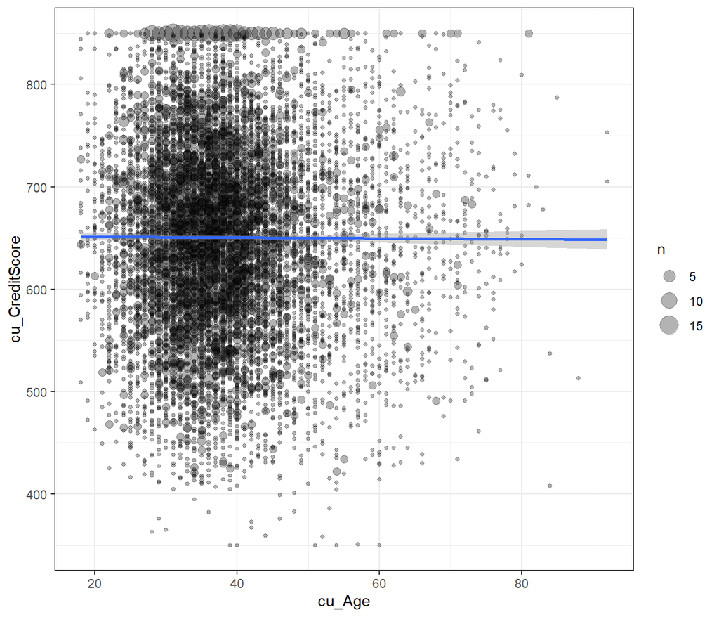

```r
## cu_Age vs cu_CreditScore

dat %>%
  ggplot(aes(cu_Age, cu_CreditScore))+
  geom_count(alpha=0.3)+
  geom_smooth(method = lm)
```

Se observa preliminarmente que no existe relación lineal entre estas. Sin embargo, se confirma con test de correlacion (Pearson y Spearman) y regresión lineal:

```r
## Pearson's product-moment correlation
cor.test(dat$cu_Age,dat$cu_CreditScore)
```

```
##
##  Pearson's product-moment correlation
##
## data:  dat$cu_Age and dat$cu_CreditScore
## t = -0.39645, df = 9998, p-value = 0.6918
## alternative hypothesis: true correlation is not equal to 0
## 95 percent confidence interval:
##  -0.02356314  0.01563638
## sample estimates:
##          cor
## -0.003964906
```

```r
## Spearman's rank correlation rho
cor.test(dat$cu_Age,dat$cu_CreditScore,method = "spearman")
```

```
##
##  Spearman's rank correlation rho
##
## data:  dat$cu_Age and dat$cu_CreditScore
## S = 1.68e+11, p-value = 0.4253
## alternative hypothesis: true rho is not equal to 0
## sample estimates:
##          rho
## -0.007974044
```

```r
## Fitting Linear Model
summary(lm(dat$cu_CreditScore ~ dat$cu_Age))
```

```
##
## Call:
## lm(formula = dat$cu_CreditScore ~ dat$cu_Age)
##
## Residuals:
##      Min       1Q   Median       3Q      Max
## -300.526  -66.785    1.358   67.045  201.009
##
## Coefficients:
##              Estimate Std. Error t value Pr(>|t|)
## (Intercept) 651.95099    3.71522 175.481   <2e-16 ***
## dat$cu_Age   -0.03654    0.09217  -0.396    0.692
## ---
## Signif. codes:  0 '***' 0.001 '**' 0.01 '*' 0.05 '.' 0.1 ' ' 1
##
## Residual standard error: 96.66 on 9998 degrees of freedom
## Multiple R-squared:  1.572e-05,  Adjusted R-squared:  -8.43e-05
## F-statistic: 0.1572 on 1 and 9998 DF,  p-value: 0.6918
```

En todos los test el p-value es mayor que 0.05, por lo que no se rechaza la H<sub>0</sub> (Pearson’s/Spearman’s: R=0 , lm: B1 = 0)

Debido a esto, se busca separar los datos entre las variables categóricas y observar si cambia la relación:

Por `Geography`:

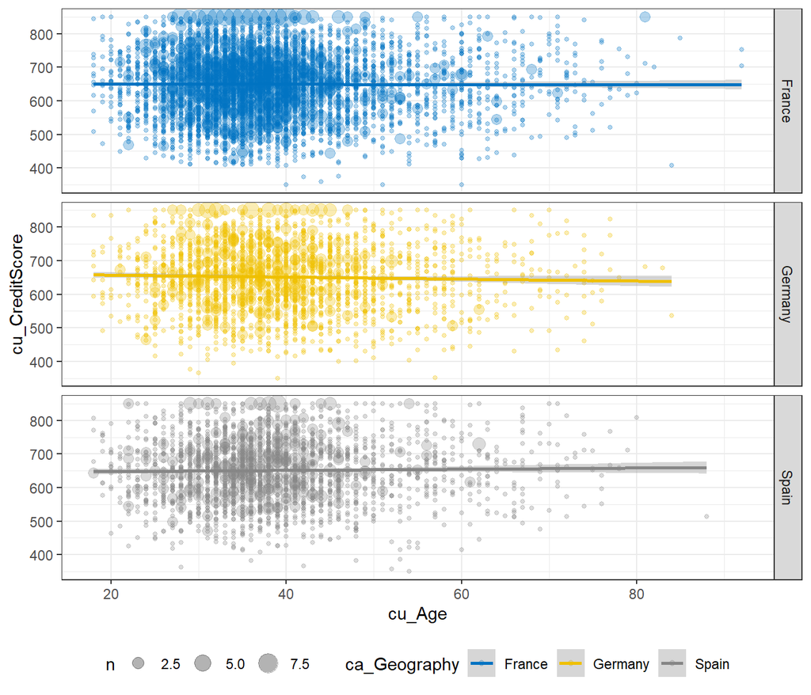

```r
## Geography

dat %>%
  ggplot(aes(cu_Age, cu_CreditScore, color=ca_Geography))+
  geom_count(alpha=0.3)+
  facet_grid(ca_Geography ~ .)+
  geom_smooth(method = lm)+
  theme(legend.position='bottom') +
  scale_color_jco()
```

Por `Gender`:

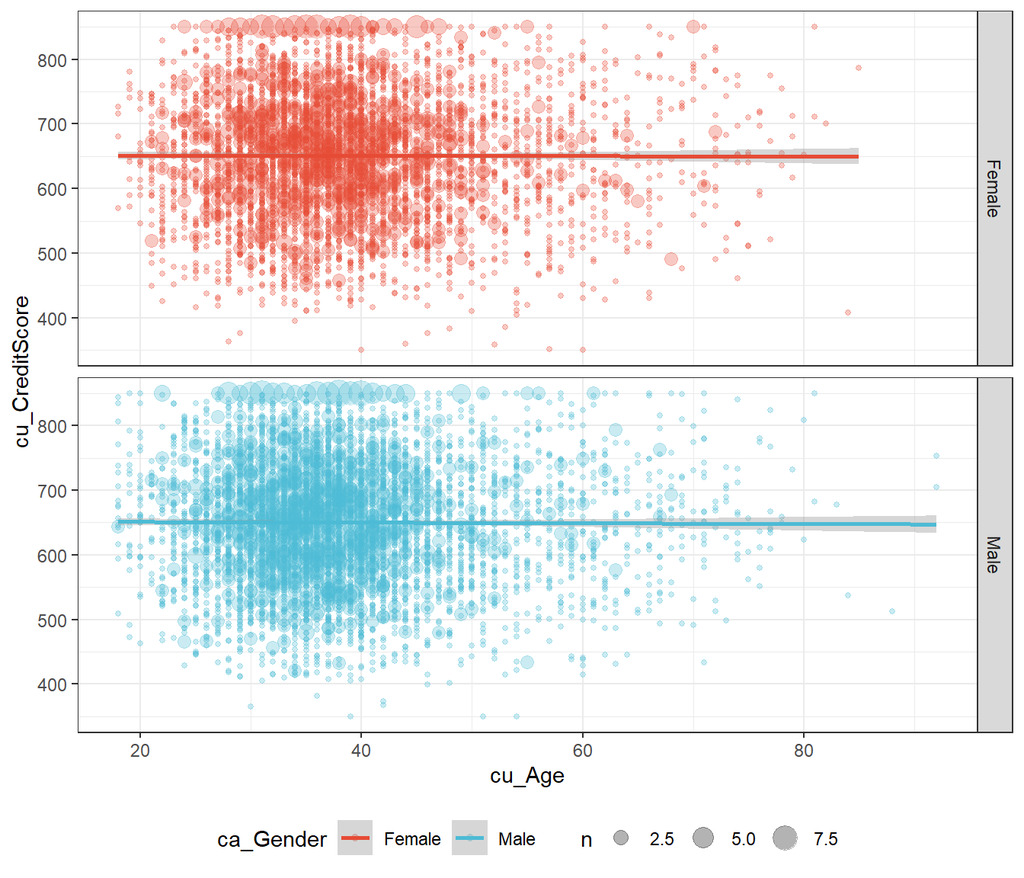

```r
## Gender

dat %>%
  ggplot(aes(cu_Age, cu_CreditScore, color=ca_Gender))+
  geom_count(alpha=0.3)+
  facet_grid(ca_Gender ~ .)+
  geom_smooth(method = lm)+
  theme(legend.position='bottom') +
  scale_color_npg()
```

Por `IsActiveMember`:

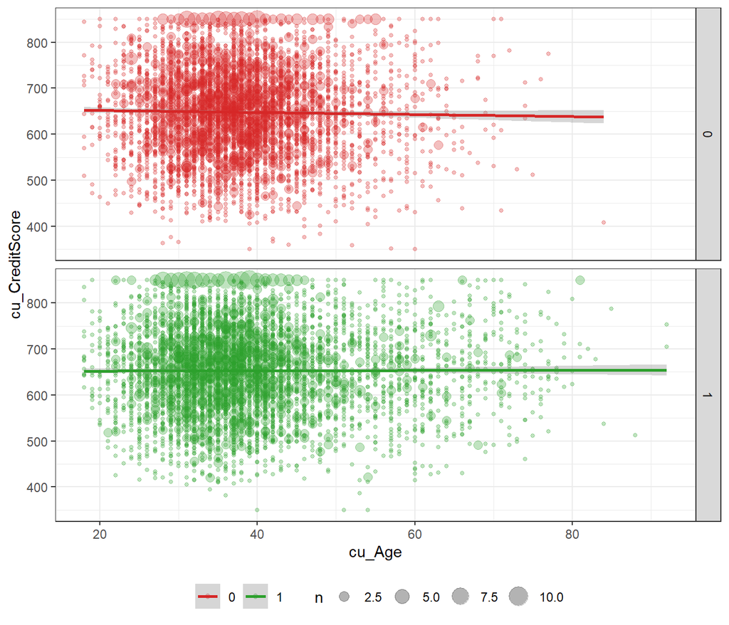

```r
## IsActiveMember
dat %>%
  ggplot(aes(cu_Age, cu_CreditScore, color=ca_IsActiveMember))+
  geom_count(alpha=0.3)+
  facet_grid(ca_IsActiveMember ~ .)+
  geom_smooth(method = lm)+
  theme(legend.position='bottom') +
  scale_colour_manual("", values = c("0" = "#d62727",
                                   "1" = "#2ca02c"))
```

Por `HasCrCard`:

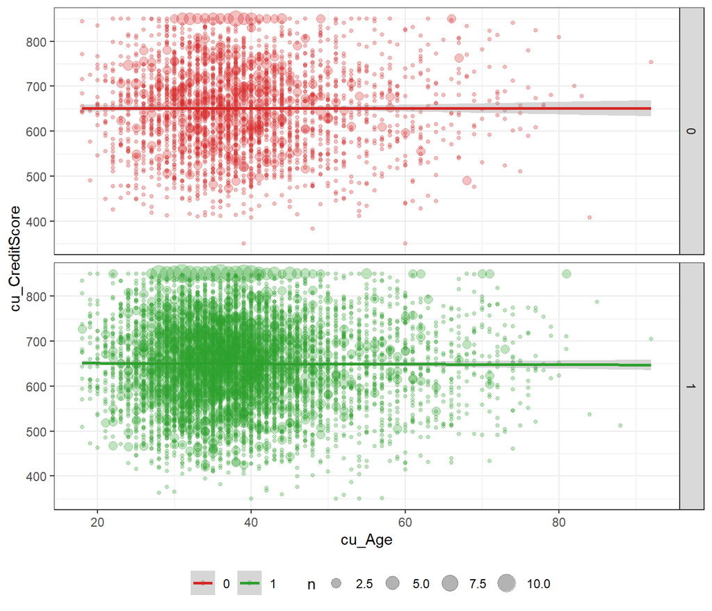

```r
## HasCrCard
dat %>%
  ggplot(aes(cu_Age, cu_CreditScore, color=ca_HasCrCard))+
  geom_count(alpha=0.3)+
  facet_grid(ca_HasCrCard ~ .)+
  geom_smooth(method = lm)+
  theme(legend.position='bottom') +
  scale_colour_manual("", values = c("0" = "#d62727",
                                   "1" = "#2ca02c"))
```

Visualmente es posible identificar que no hay relación significativa entre la edad y Credit Score entre cada una de las categorias.

##### **EXTRA**

Se busca entonces que otras variables cuantitativa si pudieran estar relacionadas con el `CreditScore`:

```r
dat %>%
  select(starts_with("cu")) %>%
  cor() %>%
  round(2)
```

```
##                    cu_CreditScore cu_Age cu_Balance cu_EstimatedSalary
## cu_CreditScore               1.00   0.00       0.01               0.00
## cu_Age                       0.00   1.00       0.03              -0.01
## cu_Balance                   0.01   0.03       1.00               0.01
## cu_EstimatedSalary           0.00  -0.01       0.01               1.00
## cu_Tenure                    0.00  -0.01      -0.01               0.01
## cu_NumOfProducts             0.01  -0.03      -0.30               0.01
##                    cu_Tenure cu_NumOfProducts
## cu_CreditScore          0.00             0.01
## cu_Age                 -0.01            -0.03
## cu_Balance             -0.01            -0.30
## cu_EstimatedSalary      0.01             0.01
## cu_Tenure               1.00             0.01
## cu_NumOfProducts        0.01             1.00
```

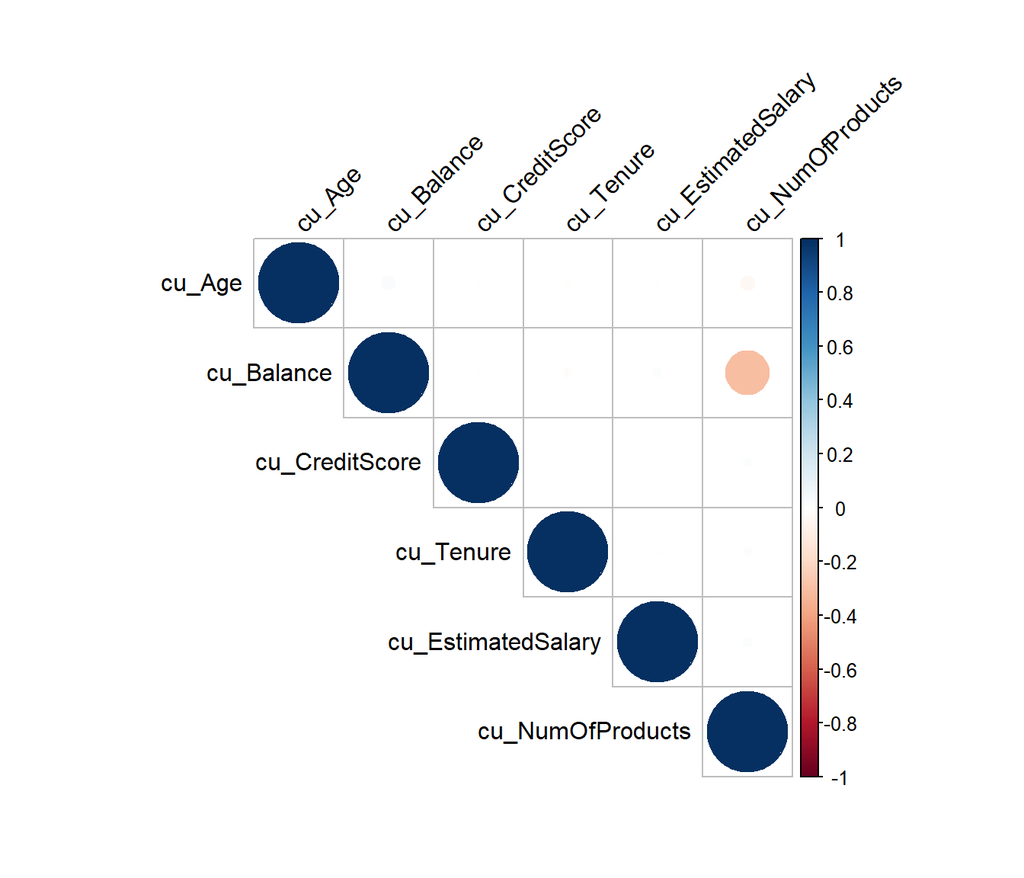

```r
dat %>%
  select(starts_with("cu")) %>%
  cor() %>%
  corrplot(type = "upper", order = "hclust",
         tl.col = "black", tl.srt = 45)
```

Como se observa, no existe relación significativa a primera vista entre `CreditScore` y el resto de variables cuantitativas.